# Coursera Practical Machine Learning Assignment (Yee Ling, Foo)

Foo Yee Ling

Saturday, June 21, 2014

This assignment requires the use of sensors data from 6 fitness enthusiasts to build a model to classify the correct and incorrect use of the fitness equipment.

The codes run on R using the Caret and Kernlab package.

```r
library(caret)
library(kernlab)
set.seed(327)
```

Import the full data from its source (http://groupware.les.inf.puc-rio.br/har) and use a subset of the training data that gives the sensors readings and all the outcome for the 5 different classes. Select 8000 rows out of the 39242 observations to build and validate the model.

```r
pmldataA = read.csv(file="pml-training-all1.csv")
pmldata = pmldataA[sample(nrow(pmldataA),size=8000,replace=FALSE),]
```

To start the modeling process, splice the data with 70% of it to be used for training and the remaining for prediction and testing.

```r
inTrain = createDataPartition(y=pmldata$classe, p=.7, list=FALSE)

pmlTr = pmldata[inTrain,] ## training data
pmlTt = pmldata[-inTrain,] ## testing data

dim(pmlTr)
```

```
## [1] 5603   53
```

```r
dim(pmlTt)
```

```
## [1] 2397   53
```

In view of the large number of predictors in the data, a Principal Component Analysis (PCA) can be done as a pre-processing step to reduce the number of predictors.

```r
## use pca
preProc = preProcess(pmlTr[,-53], method="pca" )
preProc
```

```
##
## Call:
## preProcess.default(x = pmlTr[, -53], method = "pca")
##
## Created from 5603 samples and 52 variables
## Pre-processing: principal component signal extraction, scaled, centered
##
## PCA needed 26 components to capture 95 percent of the variance
```

In this dataset, 26 components are kept to capture 95 percent of the variance.

A Support Vector Machine (SVM) classification model is then applied on the reduced training dataset using a 10-fold cross-validation.

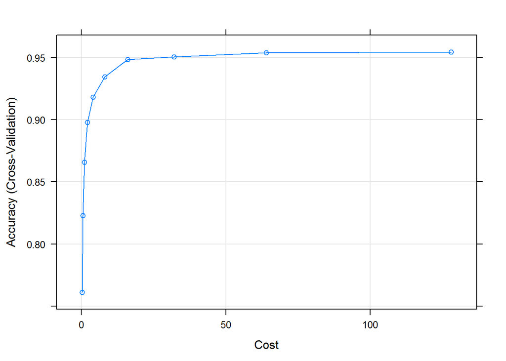

```r
pmlTrPCA = predict(preProc, pmlTr[,-53]) ## PCA treated training data
pmlModelPCA = train(pmlTr$classe ~., method = "svmRadial", tuneLength = 10, preProc = c("center","scale"), trControl = trainControl(method = "cv"), data = pmlTrPCA)
plot(pmlModelPCA, metric="Accuracy")
```

With the use of cross-validation, the accuracy of the the model is high at 95% and above.

Next, to find the out-of-sample errors, the test data is pre-processed with the PCA model and the outcome is predicted using the SVM model.

```r
pmlTtPCA = predict(preProc, pmlTt[,-53]) ## PCA treated test data
predClasse = predict(pmlModelPCA, pmlTtPCA) ## apply the model on the treated data
confusionMatrix(predClasse,pmlTt$classe)
```

```
## Confusion Matrix and Statistics
##
##           Reference
## Prediction   A   B   C   D   E
##          A 683  18   4   0   0
##          B  13 426   5   0   2
##          C   3  12 397  18  11
##          D   0   0   7 371   2
##          E   3   1   2   2 417
##
## Overall Statistics
##
##                Accuracy : 0.957
##                  95% CI : (0.948, 0.965)
##     No Information Rate : 0.293
##     P-Value [Acc > NIR] : <2e-16
##
##                   Kappa : 0.946
##  Mcnemar's Test P-Value : NA
##
## Statistics by Class:
##
##                      Class: A Class: B Class: C Class: D Class: E
## Sensitivity             0.973    0.932    0.957    0.949    0.965
## Specificity             0.987    0.990    0.978    0.996    0.996
## Pos Pred Value          0.969    0.955    0.900    0.976    0.981
## Neg Pred Value          0.989    0.984    0.991    0.990    0.992
## Prevalence              0.293    0.191    0.173    0.163    0.180
## Detection Rate          0.285    0.178    0.166    0.155    0.174
## Detection Prevalence    0.294    0.186    0.184    0.159    0.177
## Balanced Accuracy       0.980    0.961    0.967    0.972    0.981
```

```r
pmldataT = read.csv("pml-testing1.csv")
pmlTtPCA20 = predict(preProc, pmldataT[,-53])
predict(pmlModelPCA, pmlTtPCA20)
```

```
##  [1] B A B B A E D B A A B C B A E E A B A B
## Levels: A B C D E
```